# index

Exploratory Data Analysis on Titanic dataset

2024/05/22 by *Sabrina*

#### 1. Import the required libraries

Import Pandas and Matplotlib packages foe data manuplication and visualization.

```python
import pandas as pd
import matplotlib.pyplot as plt
```

Pandas is a package to handle table type dataset. Matplotlib is a package to draw various charts.

#### 2. Load the dataset

Load the Titanic dataset from a CSV file named 'tit.csv' into a Pandas DataFrame.

```python
df = pd.read_csv('tit.csv')
print(df)
```

```
     PassengerId  Survived  Pclass  \
0              1         0       3
1              2         1       1
2              3         1       3
3              4         1       1
4              5         0       3
..           ...       ...     ...
886          887         0       2
887          888         1       1
888          889         0       3
889          890         1       1
890          891         0       3

                                                  Name     Sex   Age  SibSp  \
0                              Braund, Mr. Owen Harris    male  22.0      1
```

[output cut: 25 more lines]

The output shows what the data is, including passenfer ID, pclassm ticket and so on. Also, we can see the data is 891 rows* 12 columes. The command head is to show the top few rows of this dataset.

#### 3. Data Exploration

(1) Display the first few rows of the dataset to understand its structure.

```python
print(df.head())
```

```
   PassengerId  Survived  Pclass  \
0            1         0       3
1            2         1       1
2            3         1       3
3            4         1       1
4            5         0       3

                                                Name     Sex   Age  SibSp  \
0                            Braund, Mr. Owen Harris    male  22.0      1
1  Cumings, Mrs. John Bradley (Florence Briggs Th...  female  38.0      1
2                             Heikkinen, Miss. Laina  female  26.0      0
3       Futrelle, Mrs. Jacques Heath (Lily May Peel)  female  35.0      1
4                           Allen, Mr. William Henry    male  35.0      0

   Parch            Ticket     Fare Cabin Embarked
0      0         A/5 21171   7.2500   NaN        S
1      0          PC 17599  71.2833   C85        C
2      0  STON/O2. 3101282   7.9250   NaN        S
3      0            113803  53.1000  C123        S
4      0            373450   8.0500   NaN        S
```

the output is to show what the content is in first rows, also show the total 12 columns.

(2) Print information about the colums and their data types.

```python
print(df.info())
```

```
<class 'pandas.core.frame.DataFrame'>
RangeIndex: 891 entries, 0 to 890
Data columns (total 12 columns):
 #   Column       Non-Null Count  Dtype
---  ------       --------------  -----
 0   PassengerId  891 non-null    int64
 1   Survived     891 non-null    int64
 2   Pclass       891 non-null    int64
 3   Name         891 non-null    object
 4   Sex          891 non-null    object
 5   Age          714 non-null    float64
 6   SibSp        891 non-null    int64
 7   Parch        891 non-null    int64
 8   Ticket       891 non-null    object
 9   Fare         891 non-null    float64
 10  Cabin        204 non-null    object
 11  Embarked     889 non-null    object
dtypes: float64(2), int64(5), object(5)
memory usage: 83.7+ KB
None
```

to see what is the information and some detail message of this data. understanding the total coluns of this data and about the memory usuage and so on.

(3) Show summary statistics for numerical columns

```python
print(df.describe())
```

```
       PassengerId    Survived      Pclass         Age       SibSp  \
count   891.000000  891.000000  891.000000  714.000000  891.000000
mean    446.000000    0.383838    2.308642   29.699118    0.523008
std     257.353842    0.486592    0.836071   14.526497    1.102743
min       1.000000    0.000000    1.000000    0.420000    0.000000
25%     223.500000    0.000000    2.000000   20.125000    0.000000
50%     446.000000    0.000000    3.000000   28.000000    0.000000
75%     668.500000    1.000000    3.000000   38.000000    1.000000
max     891.000000    1.000000    3.000000   80.000000    8.000000

            Parch        Fare
count  891.000000  891.000000
mean     0.381594   32.204208
std      0.806057   49.693429
min      0.000000    0.000000
25%      0.000000    7.910400
50%      0.000000   14.454200
75%      0.000000   31.000000
max      6.000000  512.329200
```

to see the information after the data has been analyzing, like the count, means, min, max...vlaue.

#### 4. Data Cleaning

```python
print('/nNumber of missing value per column:')
print(df.isnull().sum())
```

```
/nNumber of missing value per column:
PassengerId      0
Survived         0
Pclass           0
Name             0
Sex              0
Age            177
SibSp            0
Parch            0
Ticket           0
Fare             0
Cabin          687
Embarked         2
dtype: int64
```

to find out the missing value of each columns.

(2) Perfome any necessary data transformations or cleaning steps.

```python
median_age = df['Age'].median()
print('Median age before missing vlaue:',median_age)
```

```
Median age before missing vlaue: 28.0
```

to calculate the median age before find out the missing value and the result is 28.

#### 5. Data analysis

(1) Calculate and display the count of passengers by gender.

```python
print('Count of passenger by gender:')
print(df['Sex'].value_counts())
```

```
Count of passenger by gender:
Sex
male      577
female    314
Name: count, dtype: int64
```

to see how many male and female are in this data, the female is 314 and the male is 577.

(2) Compute the average age of passengers

```python
print('Average age of passengers:')
print(df["Age"].mean())
```

```
Average age of passengers:
29.69911764705882
```

(3) determine the survival rate by passenger class.

```python
print('Survival rate by passenger class')
survival_rate = df.groupby('Pclass')['Survived'].mean()
print(survival_rate)
```

```
Survival rate by passenger class
Pclass
1    0.629630
2    0.472826
3    0.242363
Name: Survived, dtype: float64
```

to find out the survival rate by passenger class and these three class is 0.62, 0.47, 0.24.

#### 6. Data visualization

(1) Create a bar chart to visualize the survival rate by passenger class. (2) Add appropriate labels and a title to the chart.

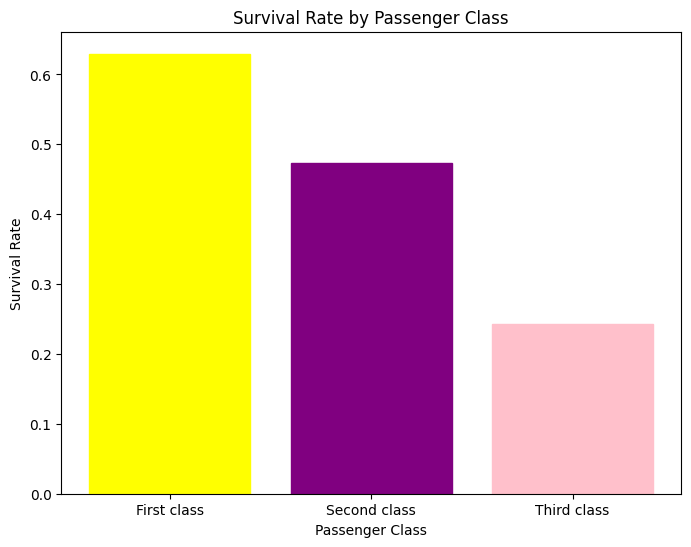

```python
import matplotlib.pyplot as plt

import pandas as pd

# Calculate the mean survival rate by passenger class

survival_rates = df.groupby('Pclass')['Survived'].mean()

# Create a bar chart

plt.figure(figsize=(8, 6))

bar = plt.bar(survival_rates.index, survival_rates.values)

# Change the color of each bar

bar[0].set_color('yellow')    # First class

bar[1].set_color('purple')  # Second class

bar[2].set_color('pink')   # Third class

# Add title and labels

plt.title('Survival Rate by Passenger Class')

plt.xlabel('Passenger Class')

plt.ylabel('Survival Rate')

plt.xticks(survival_rate.index,['First class','Second class','Third class'])

# Display the plot

plt.show()
```

We can use the code to view the graph of surviva rate by passenger class. Three clolors are imply different passenger class. The chart also show different srvival rate for each passenger classes after the calculation of the mean.